# COVID-19 Analysis

COVID-19 is perhaps the biggest global event of the past 20 years. The deaths, the entire shutdown of the global economy, and what are most likely lasting changes in day to day life have had a profound effect on all of us. Through all of this one of the most dangerous aspects in our new information dump stay at home lives is the non-data driven opinions we are being fed. So this notebook is an attempt at addressing some of these points and looking at a data driven view to give some clarity in murkiness that is our new normal.

```
1. How is the USA dealing with the virus compared to other countries ?
2. Is Sweden's approach to not lockdown effective ?
3. Does weather have an effect on deaths/cases ?
4. Is population density a main driving factor ?
5. Can we build a predictive model?
```

# The Data

For this analysis we will be relying on three major data sources

Population data - Provided from the UN

https://population.un.org/wpp/Download/Standard/CSV/

Testing data and Cases/Deaths data - Provided from ourworldindata.org (their sources are shown in their github)

https://github.com/owid/covid-19-data/tree/master/public/data

Covid cases and weather data - Provided from Kaggle and NOAA

https://www.kaggle.com/davidbnn92/weather-data-for-covid19-data-analysis

https://www.kaggle.com/c/covid19-global-forecasting-week-4

https://www.kaggle.com/noaa/gsod

```python
import pandas as pd
import numpy as np
import matplotlib.pyplot as plt
import seaborn as sns
```

```python
#loading loading weather data
weatherAndCases = pd.read_csv('training_data_with_weather_info_week_4.csv')
weatherAndCases.head()
```

|  | Id | Country_Region | Province_State | Date | ConfirmedCases | Fatalities | country+province | Lat | Long | day_from_jan_first | ... | min | max | stp | slp | dewp | rh | ah | wdsp | prcp | fog |
| --- | --- | --- | --- | --- | --- | --- | --- | --- | --- | --- | --- | --- | --- | --- | --- | --- | --- | --- | --- | --- | --- |
| 0 | 1 | Afghanistan | NaN | 2020-01-22 | 0.0 | 0.0 | Afghanistan- | 33.0 | 65.0 | 22 | ... | 33.6 | 54.9 | 999.9 | 1024.3 | 27.4 | 0.545709 | 0.186448 | 9.4 | 0.00 | 0 |
| 1 | 2 | Afghanistan | NaN | 2020-01-23 | 0.0 | 0.0 | Afghanistan- | 33.0 | 65.0 | 23 | ... | 32.7 | 55.9 | 999.9 | 1020.8 | 22.8 | 0.461259 | 0.163225 | 14.9 | 99.99 | 1 |
| 2 | 3 | Afghanistan | NaN | 2020-01-24 | 0.0 | 0.0 | Afghanistan- | 33.0 | 65.0 | 24 | ... | 36.9 | 43.2 | 999.9 | 1018.6 | 34.5 | 0.801794 | 0.325375 | 10.4 | 0.17 | 1 |
| 3 | 4 | Afghanistan | NaN | 2020-01-25 | 0.0 | 0.0 | Afghanistan- | 33.0 | 65.0 | 25 | ... | 37.9 | 56.3 | 999.9 | 1018.0 | 37.8 | 0.728175 | 0.214562 | 6.1 | 0.57 | 1 |
| 4 | 5 | Afghanistan | NaN | 2020-01-26 | 0.0 | 0.0 | Afghanistan- | 33.0 | 65.0 | 26 | ... | 36.1 | 53.1 | 999.9 | 1014.8 | 33.2 | 0.685513 | 0.231656 | 10.8 | 0.00 | 1 |

5 rows × 21 columns

```python
#loading testing data
covidTestingData = pd.read_csv('owid-covid-data.csv')
covidTestingData.head()
```

|  | iso_code | location | date | total_cases | new_cases | total_deaths | new_deaths | total_cases_per_million | new_cases_per_million | total_deaths_per_million | new_deaths_per_million | total_tests | new_tests | total_tests_per_thousand | new_tests_per_thousand | tests_units |
| --- | --- | --- | --- | --- | --- | --- | --- | --- | --- | --- | --- | --- | --- | --- | --- | --- |
| 0 | ABW | Aruba | 2020-03-13 | 2 | 2 | 0 | 0 | 18.733 | 18.733 | 0.0 | 0.0 | NaN | NaN | NaN | NaN | NaN |
| 1 | ABW | Aruba | 2020-03-20 | 4 | 2 | 0 | 0 | 37.465 | 18.733 | 0.0 | 0.0 | NaN | NaN | NaN | NaN | NaN |
| 2 | ABW | Aruba | 2020-03-24 | 12 | 8 | 0 | 0 | 112.395 | 74.930 | 0.0 | 0.0 | NaN | NaN | NaN | NaN | NaN |
| 3 | ABW | Aruba | 2020-03-25 | 17 | 5 | 0 | 0 | 159.227 | 46.831 | 0.0 | 0.0 | NaN | NaN | NaN | NaN | NaN |
| 4 | ABW | Aruba | 2020-03-26 | 19 | 2 | 0 | 0 | 177.959 | 18.733 | 0.0 | 0.0 | NaN | NaN | NaN | NaN | NaN |

```python
#poplulation data
populationdata = pd.read_csv('WPP2019_TotalPopulationBySex.csv')
populationdata.head()
```

|  | LocID | Location | VarID | Variant | Time | MidPeriod | PopMale | PopFemale | PopTotal | PopDensity |
| --- | --- | --- | --- | --- | --- | --- | --- | --- | --- | --- |
| 0 | 4 | Afghanistan | 2 | Medium | 1950 | 1950.5 | 4099.243 | 3652.874 | 7752.117 | 11.874 |
| 1 | 4 | Afghanistan | 2 | Medium | 1951 | 1951.5 | 4134.756 | 3705.395 | 7840.151 | 12.009 |
| 2 | 4 | Afghanistan | 2 | Medium | 1952 | 1952.5 | 4174.450 | 3761.546 | 7935.996 | 12.156 |
| 3 | 4 | Afghanistan | 2 | Medium | 1953 | 1953.5 | 4218.336 | 3821.348 | 8039.684 | 12.315 |
| 4 | 4 | Afghanistan | 2 | Medium | 1954 | 1954.5 | 4266.484 | 3884.832 | 8151.316 | 12.486 |

# Data cleaning

Obviously in it's current state we can't use any of this data so we'll have to clean it.

```python
# all of our data is in 2020 and some columns are superflous
populationdata = populationdata[populationdata['Time']==2020]
populationdata = populationdata[['Location','Time','PopMale','PopFemale','PopTotal','PopDensity']]
populationdata = populationdata.drop_duplicates()
populationdata.head()
```

|  | Location | Time | PopMale | PopFemale | PopTotal | PopDensity |
| --- | --- | --- | --- | --- | --- | --- |
| 70 | Afghanistan | 2020 | 19976.265 | 18952.076 | 38928.341 | 59.627 |
| 954 | Africa | 2020 | 669878.340 | 670719.773 | 1340598.113 | 45.216 |
| 1838 | African Group | 2020 | 668995.562 | 669831.029 | 1338826.591 | 45.571 |
| 1989 | African Union | 2020 | 669307.822 | 670116.099 | 1339423.921 | 45.182 |
| 2140 | African Union: Central Africa | 2020 | 79260.910 | 79358.728 | 158619.638 | 30.066 |

```python
#join the population and testing data
populationAndTesting = populationdata.merge(covidTestingData, left_on='Location', right_on='location')
populationAndTesting.head()
```

|  | Location | Time | PopMale | PopFemale | PopTotal | PopDensity | iso_code | location | date | total_cases | ... | new_deaths | total_cases_per_million | new_cases_per_million | total_deaths_per_million | new_deaths_per_million | total_tests | new_tests | total_tests_per_thousand | new_tests_per_thousand | tests_units |
| --- | --- | --- | --- | --- | --- | --- | --- | --- | --- | --- | --- | --- | --- | --- | --- | --- | --- | --- | --- | --- | --- |
| 0 | Afghanistan | 2020 | 19976.265 | 18952.076 | 38928.341 | 59.627 | AFG | Afghanistan | 2019-12-31 | 0 | ... | 0 | 0.0 | 0.0 | 0.0 | 0.0 | NaN | NaN | NaN | NaN | NaN |
| 1 | Afghanistan | 2020 | 19976.265 | 18952.076 | 38928.341 | 59.627 | AFG | Afghanistan | 2020-01-01 | 0 | ... | 0 | 0.0 | 0.0 | 0.0 | 0.0 | NaN | NaN | NaN | NaN | NaN |
| 2 | Afghanistan | 2020 | 19976.265 | 18952.076 | 38928.341 | 59.627 | AFG | Afghanistan | 2020-01-02 | 0 | ... | 0 | 0.0 | 0.0 | 0.0 | 0.0 | NaN | NaN | NaN | NaN | NaN |
| 3 | Afghanistan | 2020 | 19976.265 | 18952.076 | 38928.341 | 59.627 | AFG | Afghanistan | 2020-01-03 | 0 | ... | 0 | 0.0 | 0.0 | 0.0 | 0.0 | NaN | NaN | NaN | NaN | NaN |
| 4 | Afghanistan | 2020 | 19976.265 | 18952.076 | 38928.341 | 59.627 | AFG | Afghanistan | 2020-01-04 | 0 | ... | 0 | 0.0 | 0.0 | 0.0 | 0.0 | NaN | NaN | NaN | NaN | NaN |

5 rows × 22 columns

```python
populationAndTesting.dtypes
```

```
Location                     object
Time                          int64
PopMale                     float64
PopFemale                   float64
PopTotal                    float64
PopDensity                  float64
iso_code                     object
location                     object
date                         object
total_cases                   int64
new_cases                     int64
total_deaths                  int64
new_deaths                    int64
total_cases_per_million     float64
new_cases_per_million       float64
total_deaths_per_million    float64
new_deaths_per_million      float64
total_tests                 float64
new_tests                   float64
total_tests_per_thousand    float64
new_tests_per_thousand      float64
tests_units                  object
dtype: object
```

```python
populationAndTesting.head()
```

|  | Location | Time | PopMale | PopFemale | PopTotal | PopDensity | iso_code | location | date | total_cases | ... | new_deaths | total_cases_per_million | new_cases_per_million | total_deaths_per_million | new_deaths_per_million | total_tests | new_tests | total_tests_per_thousand | new_tests_per_thousand | tests_units |
| --- | --- | --- | --- | --- | --- | --- | --- | --- | --- | --- | --- | --- | --- | --- | --- | --- | --- | --- | --- | --- | --- |
| 0 | Afghanistan | 2020 | 19976.265 | 18952.076 | 38928.341 | 59.627 | AFG | Afghanistan | 2019-12-31 | 0 | ... | 0 | 0.0 | 0.0 | 0.0 | 0.0 | NaN | NaN | NaN | NaN | NaN |
| 1 | Afghanistan | 2020 | 19976.265 | 18952.076 | 38928.341 | 59.627 | AFG | Afghanistan | 2020-01-01 | 0 | ... | 0 | 0.0 | 0.0 | 0.0 | 0.0 | NaN | NaN | NaN | NaN | NaN |
| 2 | Afghanistan | 2020 | 19976.265 | 18952.076 | 38928.341 | 59.627 | AFG | Afghanistan | 2020-01-02 | 0 | ... | 0 | 0.0 | 0.0 | 0.0 | 0.0 | NaN | NaN | NaN | NaN | NaN |
| 3 | Afghanistan | 2020 | 19976.265 | 18952.076 | 38928.341 | 59.627 | AFG | Afghanistan | 2020-01-03 | 0 | ... | 0 | 0.0 | 0.0 | 0.0 | 0.0 | NaN | NaN | NaN | NaN | NaN |
| 4 | Afghanistan | 2020 | 19976.265 | 18952.076 | 38928.341 | 59.627 | AFG | Afghanistan | 2020-01-04 | 0 | ... | 0 | 0.0 | 0.0 | 0.0 | 0.0 | NaN | NaN | NaN | NaN | NaN |

5 rows × 22 columns

```python
#clearly some countries dont match up so lets fix that

print(len(populationdata['Location'].unique()))
print(len(covidTestingData['location'].unique()))
print(len(populationAndTesting['Location'].unique()))
print(set(covidTestingData['location'])-set(populationAndTesting['Location']))
```

[output not shown]

```python
#most of these we can disregard since they are pretty small countries we wont use in our analyssi
#but some countries we cant look past
#United States, Hong Kong, Bolivia, Russia, etc..
#we will have to do a map and transform on these data points

def changecountryname(x):
    countryMap = {"United States of America":"United States",
             "China, Hong Kong SAR": "Hong Kong",
             "Bolivia (Plurinational State of)":"Bolivia",
             "Russian Federation":"Russia",
             "Viet Nam": "Vietnam",
             "China, Taiwan Province of China":"Taiwan",
             "Iran (Islamic Republic of)":"Iran",
             "Republic of Korea":"South Korea",
             "United Republic of Tanzania": "Tanzania",
             "Czechia":"Czech Republic",
             "Democratic Republic of the Congo":"Democratic Republic of Congo",
             "Syrian Arab Republic":"Syria",
             "Venezuela (Bolivarian Republic of)":"Venezuela"}
    if x in countryMap.keys():
        return countryMap[x]
    else:
        return x
populationdata['New_Country_Code'] = populationdata.Location.apply(lambda x: changecountryname(x))
```

```python
populationdata.head()
```

|  | Location | Time | PopMale | PopFemale | PopTotal | PopDensity | New_Country_Code |
| --- | --- | --- | --- | --- | --- | --- | --- |
| 70 | Afghanistan | 2020 | 19976.265 | 18952.076 | 38928.341 | 59.627 | Afghanistan |
| 954 | Africa | 2020 | 669878.340 | 670719.773 | 1340598.113 | 45.216 | Africa |
| 1838 | African Group | 2020 | 668995.562 | 669831.029 | 1338826.591 | 45.571 | African Group |
| 1989 | African Union | 2020 | 669307.822 | 670116.099 | 1339423.921 | 45.182 | African Union |
| 2140 | African Union: Central Africa | 2020 | 79260.910 | 79358.728 | 158619.638 | 30.066 | African Union: Central Africa |

```python
#join the population and testing data
populationAndTesting = populationdata.merge(covidTestingData, left_on='New_Country_Code', right_on='location')
populationAndTesting.head()
```

|  | Location | Time | PopMale | PopFemale | PopTotal | PopDensity | New_Country_Code | iso_code | location | date | ... | new_deaths | total_cases_per_million | new_cases_per_million | total_deaths_per_million | new_deaths_per_million | total_tests | new_tests | total_tests_per_thousand | new_tests_per_thousand | tests_units |
| --- | --- | --- | --- | --- | --- | --- | --- | --- | --- | --- | --- | --- | --- | --- | --- | --- | --- | --- | --- | --- | --- |
| 0 | Afghanistan | 2020 | 19976.265 | 18952.076 | 38928.341 | 59.627 | Afghanistan | AFG | Afghanistan | 2019-12-31 | ... | 0 | 0.0 | 0.0 | 0.0 | 0.0 | NaN | NaN | NaN | NaN | NaN |
| 1 | Afghanistan | 2020 | 19976.265 | 18952.076 | 38928.341 | 59.627 | Afghanistan | AFG | Afghanistan | 2020-01-01 | ... | 0 | 0.0 | 0.0 | 0.0 | 0.0 | NaN | NaN | NaN | NaN | NaN |
| 2 | Afghanistan | 2020 | 19976.265 | 18952.076 | 38928.341 | 59.627 | Afghanistan | AFG | Afghanistan | 2020-01-02 | ... | 0 | 0.0 | 0.0 | 0.0 | 0.0 | NaN | NaN | NaN | NaN | NaN |
| 3 | Afghanistan | 2020 | 19976.265 | 18952.076 | 38928.341 | 59.627 | Afghanistan | AFG | Afghanistan | 2020-01-03 | ... | 0 | 0.0 | 0.0 | 0.0 | 0.0 | NaN | NaN | NaN | NaN | NaN |
| 4 | Afghanistan | 2020 | 19976.265 | 18952.076 | 38928.341 | 59.627 | Afghanistan | AFG | Afghanistan | 2020-01-04 | ... | 0 | 0.0 | 0.0 | 0.0 | 0.0 | NaN | NaN | NaN | NaN | NaN |

5 rows × 23 columns

```python
#Test new missing set
print(set(covidTestingData['location'])-set(populationAndTesting['New_Country_Code']))
```

```
{'Jersey', 'Vatican', 'Brunei', 'Timor', 'Macedonia', 'Laos', 'International', 'Moldova', 'Faeroe Islands', 'Kosovo', 'Swaziland', 'Bonaire Sint Eustatius and Saba', 'Curacao', 'Cape Verde', 'Palestine', 'Falkland Islands', 'Guernsey', "Cote d'Ivoire"}
```

```python
populationAndTesting.dtypes
```

```
Location                     object
Time                          int64
PopMale                     float64
PopFemale                   float64
PopTotal                    float64
PopDensity                  float64
New_Country_Code             object
iso_code                     object
location                     object
date                         object
total_cases                   int64
new_cases                     int64
total_deaths                  int64
new_deaths                    int64
total_cases_per_million     float64
new_cases_per_million       float64
total_deaths_per_million    float64
new_deaths_per_million      float64
total_tests                 float64
new_tests                   float64
total_tests_per_thousand    float64
new_tests_per_thousand      float64
tests_units                  object
dtype: object
```

```python
#the weather data we're good with but we will be adding some
#population information to standardize our points
populationandweather = populationdata.merge(weatherAndCases, left_on='New_Country_Code', right_on='Country_Region')
populationandweather.head()
```

|  | Location | Time | PopMale | PopFemale | PopTotal | PopDensity | New_Country_Code | Id | Country_Region | Province_State | ... | min | max | stp | slp | dewp | rh | ah | wdsp | prcp | fog |
| --- | --- | --- | --- | --- | --- | --- | --- | --- | --- | --- | --- | --- | --- | --- | --- | --- | --- | --- | --- | --- | --- |
| 0 | Afghanistan | 2020 | 19976.265 | 18952.076 | 38928.341 | 59.627 | Afghanistan | 1 | Afghanistan | NaN | ... | 33.6 | 54.9 | 999.9 | 1024.3 | 27.4 | 0.545709 | 0.186448 | 9.4 | 0.00 | 0 |
| 1 | Afghanistan | 2020 | 19976.265 | 18952.076 | 38928.341 | 59.627 | Afghanistan | 2 | Afghanistan | NaN | ... | 32.7 | 55.9 | 999.9 | 1020.8 | 22.8 | 0.461259 | 0.163225 | 14.9 | 99.99 | 1 |
| 2 | Afghanistan | 2020 | 19976.265 | 18952.076 | 38928.341 | 59.627 | Afghanistan | 3 | Afghanistan | NaN | ... | 36.9 | 43.2 | 999.9 | 1018.6 | 34.5 | 0.801794 | 0.325375 | 10.4 | 0.17 | 1 |
| 3 | Afghanistan | 2020 | 19976.265 | 18952.076 | 38928.341 | 59.627 | Afghanistan | 4 | Afghanistan | NaN | ... | 37.9 | 56.3 | 999.9 | 1018.0 | 37.8 | 0.728175 | 0.214562 | 6.1 | 0.57 | 1 |
| 4 | Afghanistan | 2020 | 19976.265 | 18952.076 | 38928.341 | 59.627 | Afghanistan | 5 | Afghanistan | NaN | ... | 36.1 | 53.1 | 999.9 | 1014.8 | 33.2 | 0.685513 | 0.231656 | 10.8 | 0.00 | 1 |

5 rows × 28 columns

```python
#clearly some countries dont match up so lets fix that
print(len(populationdata['Location'].unique()))
print(len(weatherAndCases['Country_Region'].unique()))
print(len(populationandweather['Location'].unique()))
print(set(weatherAndCases['Country_Region'])-set(populationandweather['New_Country_Code']))
```

```
474
184
169
{'Burma', 'West Bank and Gaza', 'Diamond Princess', 'Brunei', 'Korea, South', 'Laos', 'Moldova', 'MS Zaandam', 'Kosovo', 'Congo (Brazzaville)', 'Czechia', 'US', 'Taiwan*', "Cote d'Ivoire", 'Congo (Kinshasa)'}
```

```python
#diamond princess and MS Zaandam are a cruise liners so we obvioulsy dont need that
#from this list to simplify things we're only going to change the some of the countries

def changecountryname2(x):
    countryMap = {
        "United States":"US",
        "Taiwan":"Taiwan*",
        "South Korea":"Korea, South",
        "Czech Republic":"Czechia"}
    if x in countryMap.keys():
        return countryMap[x]
    else:
        return x
populationdata['New_Country_Code_Weather'] = populationdata.New_Country_Code.apply(lambda x: changecountryname2(x))
```

```python
#the weather data we're good with but we will be adding some
#population information to standardize our points
populationandweather = populationdata.merge(weatherAndCases, left_on='New_Country_Code_Weather', right_on='Country_Region')
populationandweather.head()
```

|  | Location | Time | PopMale | PopFemale | PopTotal | PopDensity | New_Country_Code | New_Country_Code_Weather | Id | Country_Region | ... | min | max | stp | slp | dewp | rh | ah | wdsp | prcp | fog |
| --- | --- | --- | --- | --- | --- | --- | --- | --- | --- | --- | --- | --- | --- | --- | --- | --- | --- | --- | --- | --- | --- |
| 0 | Afghanistan | 2020 | 19976.265 | 18952.076 | 38928.341 | 59.627 | Afghanistan | Afghanistan | 1 | Afghanistan | ... | 33.6 | 54.9 | 999.9 | 1024.3 | 27.4 | 0.545709 | 0.186448 | 9.4 | 0.00 | 0 |
| 1 | Afghanistan | 2020 | 19976.265 | 18952.076 | 38928.341 | 59.627 | Afghanistan | Afghanistan | 2 | Afghanistan | ... | 32.7 | 55.9 | 999.9 | 1020.8 | 22.8 | 0.461259 | 0.163225 | 14.9 | 99.99 | 1 |
| 2 | Afghanistan | 2020 | 19976.265 | 18952.076 | 38928.341 | 59.627 | Afghanistan | Afghanistan | 3 | Afghanistan | ... | 36.9 | 43.2 | 999.9 | 1018.6 | 34.5 | 0.801794 | 0.325375 | 10.4 | 0.17 | 1 |
| 3 | Afghanistan | 2020 | 19976.265 | 18952.076 | 38928.341 | 59.627 | Afghanistan | Afghanistan | 4 | Afghanistan | ... | 37.9 | 56.3 | 999.9 | 1018.0 | 37.8 | 0.728175 | 0.214562 | 6.1 | 0.57 | 1 |
| 4 | Afghanistan | 2020 | 19976.265 | 18952.076 | 38928.341 | 59.627 | Afghanistan | Afghanistan | 5 | Afghanistan | ... | 36.1 | 53.1 | 999.9 | 1014.8 | 33.2 | 0.685513 | 0.231656 | 10.8 | 0.00 | 1 |

5 rows × 29 columns

```python
#clearly some countries dont match up so lets fix that
print(len(populationdata['Location'].unique()))
print(len(weatherAndCases['Country_Region'].unique()))
print(len(populationandweather['Location'].unique()))
print(set(weatherAndCases['Country_Region'])-set(populationandweather['New_Country_Code_Weather']))
```

```
474
184
173
{'Burma', 'West Bank and Gaza', 'Diamond Princess', 'Brunei', 'Laos', 'Moldova', 'MS Zaandam', 'Kosovo', 'Congo (Brazzaville)', "Cote d'Ivoire", 'Congo (Kinshasa)'}
```

# Variable Creation

```python
from dateutil import parser
populationAndTesting['DTDate'] = populationAndTesting.date.apply(lambda x: parser.parse(x))
populationAndTesting.head()
```

|  | Location | Time | PopMale | PopFemale | PopTotal | PopDensity | New_Country_Code | iso_code | location | date | ... | total_cases_per_million | new_cases_per_million | total_deaths_per_million | new_deaths_per_million | total_tests | new_tests | total_tests_per_thousand | new_tests_per_thousand | tests_units | DTDate |
| --- | --- | --- | --- | --- | --- | --- | --- | --- | --- | --- | --- | --- | --- | --- | --- | --- | --- | --- | --- | --- | --- |
| 0 | Afghanistan | 2020 | 19976.265 | 18952.076 | 38928.341 | 59.627 | Afghanistan | AFG | Afghanistan | 2019-12-31 | ... | 0.0 | 0.0 | 0.0 | 0.0 | NaN | NaN | NaN | NaN | NaN | 2019-12-31 |
| 1 | Afghanistan | 2020 | 19976.265 | 18952.076 | 38928.341 | 59.627 | Afghanistan | AFG | Afghanistan | 2020-01-01 | ... | 0.0 | 0.0 | 0.0 | 0.0 | NaN | NaN | NaN | NaN | NaN | 2020-01-01 |
| 2 | Afghanistan | 2020 | 19976.265 | 18952.076 | 38928.341 | 59.627 | Afghanistan | AFG | Afghanistan | 2020-01-02 | ... | 0.0 | 0.0 | 0.0 | 0.0 | NaN | NaN | NaN | NaN | NaN | 2020-01-02 |
| 3 | Afghanistan | 2020 | 19976.265 | 18952.076 | 38928.341 | 59.627 | Afghanistan | AFG | Afghanistan | 2020-01-03 | ... | 0.0 | 0.0 | 0.0 | 0.0 | NaN | NaN | NaN | NaN | NaN | 2020-01-03 |
| 4 | Afghanistan | 2020 | 19976.265 | 18952.076 | 38928.341 | 59.627 | Afghanistan | AFG | Afghanistan | 2020-01-04 | ... | 0.0 | 0.0 | 0.0 | 0.0 | NaN | NaN | NaN | NaN | NaN | 2020-01-04 |

5 rows × 24 columns

```python
populationAndTesting.dtypes
```

```
Location                            object
Time                                 int64
PopMale                            float64
PopFemale                          float64
PopTotal                           float64
PopDensity                         float64
New_Country_Code                    object
iso_code                            object
location                            object
date                                object
total_cases                          int64
new_cases                            int64
total_deaths                         int64
new_deaths                           int64
total_cases_per_million            float64
new_cases_per_million              float64
total_deaths_per_million           float64
new_deaths_per_million             float64
total_tests                        float64
new_tests                          float64
total_tests_per_thousand           float64
new_tests_per_thousand             float64
tests_units                         object
DTDate                      datetime64[ns]
dtype: object
```

```python
#cleaning up data
populationAndTesting = populationAndTesting[['Location','PopTotal','PopDensity',
                                             'total_cases','total_deaths',
                                             'total_tests','DTDate']]
```

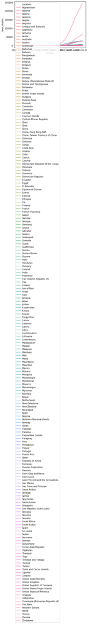

```python
ax = sns.lineplot(x="DTDate", y="total_deaths", hue="Location",
                  data=populationAndTesting)
```

Wow that is one ugly graph

Lets get rid of a lot of the smaller countries for our analysis

```python
populationAndTesting = populationAndTesting.sort_values(by='PopTotal', ascending=False)
populationAndTesting.head()
```

|  | Location | PopTotal | PopDensity | total_cases | total_deaths | total_tests | DTDate |
| --- | --- | --- | --- | --- | --- | --- | --- |
| 13816 | World | 7794798.729 | 59.917 | 69265 | 1669 | NaN | 2020-02-16 |
| 13867 | World | 7794798.729 | 59.917 | 1316988 | 75125 | NaN | 2020-04-07 |
| 13880 | World | 7794798.729 | 59.917 | 2350993 | 167483 | NaN | 2020-04-20 |
| 13879 | World | 7794798.729 | 59.917 | 2278484 | 162447 | NaN | 2020-04-19 |
| 13878 | World | 7794798.729 | 59.917 | 2199460 | 155954 | NaN | 2020-04-18 |

Interesting, we have world data. Lets save that for later

```python
populationAndTestingWorld = populationAndTesting[populationAndTesting['Location']=='World']
populationAndTesting = populationAndTesting[populationAndTesting['Location']!='World']
populationAndTesting.head()
```

|  | Location | PopTotal | PopDensity | total_cases | total_deaths | total_tests | DTDate |
| --- | --- | --- | --- | --- | --- | --- | --- |
| 2690 | China | 1439323.774 | 153.312 | 27 | 0 | NaN | 2019-12-31 |
| 2691 | China | 1439323.774 | 153.312 | 27 | 0 | NaN | 2020-01-01 |
| 2813 | China | 1439323.774 | 153.312 | 83959 | 4637 | NaN | 2020-05-02 |
| 2765 | China | 1439323.774 | 153.312 | 80995 | 3203 | NaN | 2020-03-15 |
| 2752 | China | 1439323.774 | 153.312 | 80134 | 2914 | NaN | 2020-03-02 |

```python
topCountries = populationAndTesting.Location.unique()[:25]
topCountries = np.concatenate((topCountries,['Sweden']))
topCountries
```

```
array(['China', 'India', 'United States of America', 'Indonesia',
       'Pakistan', 'Brazil', 'Nigeria', 'Bangladesh', 'Russian Federation',
       'Mexico', 'Japan', 'Ethiopia', 'Philippines', 'Egypt', 'Viet Nam',
       'Democratic Republic of the Congo', 'Turkey',
       'Iran (Islamic Republic of)', 'Germany', 'Thailand',
       'United Kingdom', 'France', 'Italy', 'United Republic of Tanzania',
       'South Africa', 'Sweden'], dtype=object)
```

```python
populationAndTestingTop = populationAndTesting[populationAndTesting['Location'].isin(topCountries)]
populationAndTestingTop.head()
```

|  | Location | PopTotal | PopDensity | total_cases | total_deaths | total_tests | DTDate |
| --- | --- | --- | --- | --- | --- | --- | --- |
| 2690 | China | 1439323.774 | 153.312 | 27 | 0 | NaN | 2019-12-31 |
| 2691 | China | 1439323.774 | 153.312 | 27 | 0 | NaN | 2020-01-01 |
| 2813 | China | 1439323.774 | 153.312 | 83959 | 4637 | NaN | 2020-05-02 |
| 2765 | China | 1439323.774 | 153.312 | 80995 | 3203 | NaN | 2020-03-15 |
| 2752 | China | 1439323.774 | 153.312 | 80134 | 2914 | NaN | 2020-03-02 |

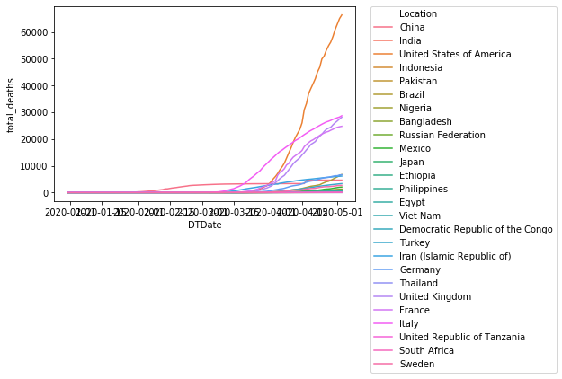

```python
ax = sns.lineplot(x="DTDate", y="total_deaths", hue="Location",
                  data=populationAndTestingTop)
plt.legend(bbox_to_anchor=(1.05, 1), loc=2, borderaxespad=0.)
plt.figure(figsize=(18, 16), dpi= 80, facecolor='w', edgecolor='k')
```

this is decieving. The us is 3rd in population. But more importantly

lets look at the testing

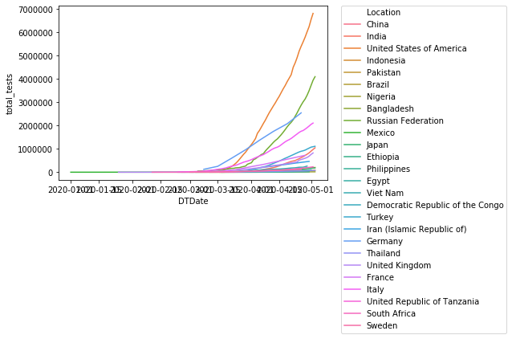

```python
ax = sns.lineplot(x="DTDate", y="total_tests", hue="Location",
                  data=populationAndTestingTop)
plt.legend(bbox_to_anchor=(1.05, 1), loc=2, borderaxespad=0.)
plt.figure(figsize=(18, 16), dpi= 80, facecolor='w', edgecolor='k')
```

It is clear that the US has vastly more tests than any other country.

```python
#lets control deaths and cases for tests
populationAndTestingTop['deaths_per_test'] = populationAndTestingTop['total_deaths'] / populationAndTestingTop['total_tests']
populationAndTestingTop.head()
set(populationAndTestingTop.dropna().Location)
```

```
{'Bangladesh',
 'Ethiopia',
 'France',
 'Germany',
 'India',
 'Indonesia',
 'Iran (Islamic Republic of)',
 'Italy',
 'Japan',
 'Mexico',
 'Nigeria',
 'Pakistan',
 'Philippines',
 'Russian Federation',
 'South Africa',
 'Sweden',
 'Thailand',
 'Turkey',
 'United Kingdom',
 'United States of America',
 'Viet Nam'}
```

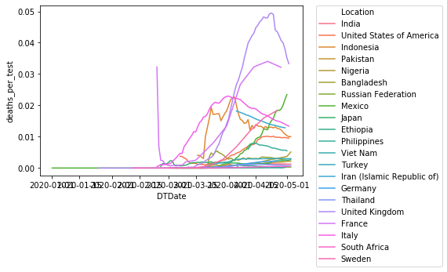

```python
ax = sns.lineplot(x="DTDate", y="deaths_per_test", hue="Location",
                  data=populationAndTestingTop.dropna())
plt.legend(bbox_to_anchor=(1.05, 1), loc=2, borderaxespad=0.)
plt.figure(figsize=(18, 16), dpi= 80, facecolor='w', edgecolor='k')
```